# Сравнение геометрических представлений сердца и их электрического отклика

## Результаты и выявленные зависимости простыми словами

Главный результат: **одинаковый объём сердца ещё не означает одинаковый электрический сигнал. Важны форма области и то, где она расположена относительно электродов.**

Получены следующие результаты.

1. **Индивидуальная форма лучше сохраняет геометрию автоматической маски, чем сфера или эллипсоид.** Это ожидаемо: она сохраняет особенности исходного сердца. Сфера теряет вытянутость и ориентацию, эллипсоид сохраняет их приближённо. Но геометрическое сходство ещё не показывает, насколько правильно воспроизводится электрический сигнал.
2. **Способ построения фигуры существенно влияет на результат.** Если подбирать сферу или эллипсоид только по совпадению с поверхностью сердца, их объём может отличаться от объёма маски на десятки процентов. Получается внешне подходящая фигура, но уже другого объёма. Поэтому сохранение объёма и совпадение формы мы оцениваем отдельно.
3. **Эллипсоид лучше сферы воспроизвёл исходный импеданс во всех шести проверенных электродных сборках.** Это результат для одной статической модели и конкретных способов построения фигур. В некоторых сборках преимущество было небольшим. Пока это основание продолжать исследование эллипсоида, а не объявлять его универсально лучшей заменой сердца.
4. **При изменении объёма сфера и эллипсоид дают заметно разные изменения сигнала.** Для диагональной сборки TEPC-2 центральная разностная оценка при симметричных изменениях объёма ±0,5% составила приблизительно:
   - индивидуальная форма — **−0,016 Ом/мл**;
   - сфера — **−0,008 Ом/мл**;
   - эллипсоид — **−0,014 Ом/мл**.

   То есть отклик эллипсоида оказался примерно **на 81% сильнее**. Свойства тканей при этом оставались одинаковыми. Причина различия — геометрия: при увеличении разных фигур сердечный материал занимает разные участки пространства, а электроды чувствуют эти участки неодинаково.
5. **Близость исходного импеданса не гарантирует правильной чувствительности.** Модель может хорошо воспроизводить исходное значение, но неверно предсказывать, насколько оно изменится при увеличении сердца. Поэтому нам нужны две отдельные проверки: совпадение исходного импеданса и совпадение его изменений. Первое сравнение изменений относительно индивидуальной формы выполнено: эллипсоид оказался ближе к ней, чем сфера. Точность этого сравнения ещё проверяется: индивидуальная форма рассчитана при 16 384 точках интегрирования на элемент, а сфера и эллипсоид — при 4096.
6. **Обнаружена существенная численная проблема при перемещении границы сердца.** Если целый конечный элемент назначать сердцу или окружающей ткани, небольшое движение границы вызывает скачкообразное изменение материала. Даже перенос без изменения размера может создавать ложное изменение объёма. Учёт частичного заполнения элементов значительно уменьшил эту ошибку. Первое локальное уточнение сетки изменило базовый импеданс на 0,373%; чувствительность на этой сетке ещё предстоит пересчитать.
7. **У индивидуальной формы увеличение и уменьшение объёма дают неодинаковый отклик.** При полуширине 0,5% односторонние оценки составляют около −0,019 и −0,012 Ом/мл. Центральная оценка усредняет эти значения и скрывает различие. Поэтому её пока нельзя использовать как единственный проверенный коэффициент перевода сигнала в объём.

**Практический вывод:** в выполненном опыте эллипсоид лучше сферы воспроизвёл и исходный импеданс, и его изменение при увеличении индивидуальной формы сердца. Это основание продолжать проверку эллипсоида. Сравнение изменений сигнала пока предварительное: число точек интегрирования различается между фигурами. Окончательный выбор требует повторения расчётов при одинаковой подробности интегрирования, проверки на уточнённой сетке и рассмотрения других условий.

## Основной результат и границы его интерпретации

В работе различаются два анатомических представления: **автоматическая маска целевой фазы** и **индивидуальная форма, полученная преобразованием опорной маски**. Первое сохраняет форму, найденную алгоритмом сегментации в каждой фазе. Второе сокращает описание изменения формы до небольшого числа параметров. Сфера и эллипсоид обеспечивают дальнейшее сокращение геометрической информации.

Первые расчёты показывают, что выбор критерия аппроксимации существенно влияет на результат. Сохранение объёма, хорошее совпадение поверхностей и близость электрического отклика являются самостоятельными требованиями. В статическом электрическом опыте эллипсоид равного объёма дал меньшую ошибку импеданса, чем сфера равного объёма, во всех шести сборках. Этот результат относится к одному состоянию одной модели и двум конкретным способам построения фигур.

Для оценки малых изменений положения и объёма выявлено ограничение: назначение целого конечного элемента одному материалу по положению его центра создаёт ступенчатую границу. Из-за этого производная дискретного объёма может существенно отличаться от производной заданного объёма даже при небольшой ошибке исходного объёма. Учёт частичного заполнения элементов уже существенно уменьшил геометрическую ошибку. Первый электрический опыт на TEPC-2 дал небольшие различия при изменении шага и подробности интегрирования. При этом чувствительность эллипсоида к объёму оказалась примерно в 1,81 раза выше, чем у сферы; в первом сравнении с индивидуальной формой эллипсоид воспроизвёл её чувствительность ближе, чем сфера. Ниже отдельно показаны результат этого сравнения и остающаяся численная неопределённость.

## 1. Постановка и организация сравнения

Цель — определить, какое сокращённое описание сердца одновременно сохраняет физиологически интерпретируемые параметры и воспроизводит электрический отклик с заданной точностью. В этом отчёте проверяются отдельные звенья этой задачи. Допустимая ошибка конечной оценки функции сердца пока не определена; порог клинической пригодности из вычислительных результатов не выводится.

Основное сравнение начинается с четырёх представлений. Полный перечень критериев приведён в реестре методов. Обозначения Г и Л относятся к способам построения сферы и эллипсоида; номера TEPC относятся к электродным сборкам.

| Представление | Необходимая геометрическая информация | Роль в сравнении |
| --- | --- | --- |
| Маска целевой фазы | Полная автоматическая сегментация данной фазы | Вычислительный анатомический ориентир |
| Индивидуальная форма | Опорная маска, объём и центр целевой фазы | Проверка сокращённого описания изменения индивидуальной формы |
| Сфера равного объёма | Объём и три координаты центра | Наиболее простое из рассматриваемых геометрических приближений |
| Эллипсоид равного объёма | Объём, центр и матрица вторых моментов | Приближение с учётом вытянутости и ориентации области |

Целое сердце, объединённая область крови и отдельные камеры определяют **область анализа**. Эти определения не подменяют различие между маской целевой фазы и индивидуальной формой. В показанном расширенном сравнении областью служит целое сердце.

## 2. Исходные данные, вычислительные условия и проверочные величины

Геометрический опыт использует три ранее выбранные фазы трёх участников. Для каждого участника рассмотрен самый длинный из имеющихся исходных циклов; в нём выбрана неопорная фаза с наибольшим абсолютным относительным изменением объёма целого сердца. Качество аппроксимации при выборе примеров не использовалось. Поэтому примеры удобны для выявления различий методов, но не являются случайной выборкой людей или фаз. Опорная фаза определяется по времени и не объявляется конечной диастолой.

Маски получены автоматической сегментацией. Независимых ручных референсов для этих фаз пока нет. У двух из трёх показанных масок область сердца касается границы КТ; искусственное замыкание поверхности в таких местах влияет на подгонку. Полученные фигуры аппроксимируют доступную маску, включая её ограничения. Объёмы и центры вычислены в физических координатах с учётом объёма вокселей. Данные разных участников и статической FEM-модели не совмещались автоматически.

Для каждой фигуры отдельно оцениваются относительная ошибка объёма, расстояние между центрами и пространственное перекрытие:

$$e_V=100\left(\frac{V_G}{V_M}-1\right),\qquad D=\frac{2|M\cap G|}{|M|+|G|},$$

где $V_M$ — объём маски, $V_G$ — аналитический объём фигуры; $e_V$ выражается в процентах; $D$ — коэффициент Dice. Для вычисления Dice маска и фигура проверяются на одной решётке центров исходных вокселей, расширенной до полного охвата обеих областей. Фигура за границами исходного массива не отсекается. Такое нулевое продолжение маски является вычислительным соглашением и не восстанавливает анатомию за пределами КТ.

Поверхность строится как изоповерхность уровня 0,5 бинарной маски без сглаживания, с нулевым дополнением по краям. На каждом треугольнике используются три точки интегрирования с одинаковыми долями его площади. Поверхностная проверка для сфер и эллипсоидов задаётся величиной

$$R_{\mathrm{surf}}=\sqrt{\sum_i w_i d_i^2},\qquad \sum_i w_i=1,$$

где $d_i$ — кратчайшее евклидово расстояние от точки поверхности маски до поверхности фигуры, в миллиметрах; $w_i$ — нормированные веса по площади. Это одностороннее расстояние «маска → фигура»; симметричной ошибкой поверхностей или расстоянием Хаусдорфа оно не является. Непосредственно измеренной ошибки анатомии оно не задаёт.

При подгонке поверхности используются веса по площади, а не одинаковый вес каждой вершины произвольной триангуляции. Для сферы и эллипсоида расстояние до поверхности имеет геометрический смысл и измеряется в миллиметрах. Алгебраическая невязка уравнения фигуры рассматривается отдельно. Уменьшение критерия, использованного при подгонке, само по себе не является независимой проверкой модели. Для новых методов сохраняются исходные приближения, бюджет вычислений и признаки сходимости.

## 3. Сравнение основных представлений

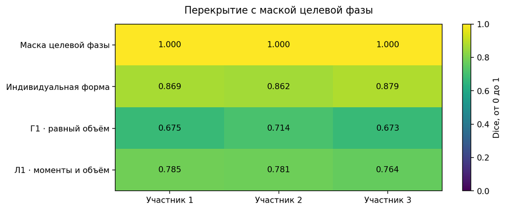

**Рисунок 1. Пространственное перекрытие четырёх основных представлений.** Единая цветовая шкала показывает Dice от 0 до 1. Маска целевой фазы имеет Dice = 1 по определению сравнения с собой; это не оценка точности автоматической сегментации. Каждая колонка относится к одной и той же маске, представленной разными способами.

В трёх показанных фазах индивидуальная форма обеспечивает Dice примерно 0,862–0,879, эллипсоид равного объёма — 0,764–0,785, сфера равного объёма — 0,673–0,714. Индивидуальная форма лучше сохраняет пространственную структуру доступной маски. Это преимущество требует дополнительной информации — полной опорной маски. Поэтому его следует учитывать вместе с требуемым объёмом исходных данных.

Варианты с поворотом и анизотропным масштабированием в этих трёх примерах не улучшили Dice относительно простого переноса и равномерного масштабирования. Дополнительные параметры не гарантируют улучшения, поскольку здесь они определяются по моментам, а не подбираются для максимизации перекрытия. Пофазные результаты и изображения на срезах КТ сохранены в отчёте 40.16.

## 4. Влияние способа построения сферы и эллипсоида

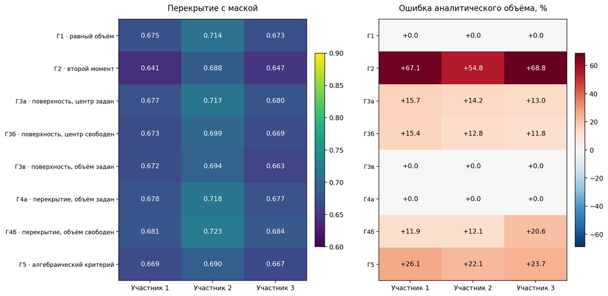

**Рисунок 2. Перекрытие и ошибка объёма для разных способов построения сферы.** Два показателя представлены раздельно. Для различимости близких результатов цветовая шкала Dice на рисунках 2 и 3 ограничена интервалом 0,60–0,90. Больший Dice означает лучшее совпадение областей; нулевая ошибка объёма означает сохранение объёма маски. Ни один из этих показателей не является электрической ошибкой.

Для методов Г3а, Г3б, Г3в и Г5 итоговые параметры на этом рисунке получены по полной площадочной квадратуре поверхности, без подвыборки. Это устраняет ошибку прореживания точек в подгонке, но сохраняет погрешность самой поверхности, полученной из маски.

Сфера, сохраняющая второй пространственный момент, в этих примерах завышает объём приблизительно на 55–69%. Подгонка поверхности и алгебраическая подгонка дают другие радиусы и центры. Поэтому название «сферическое приближение» без указания критерия недостаточно для воспроизведения результата. Если объём должен сохранять анатомический смысл, его необходимо фиксировать непосредственно либо отдельно проверять ошибку свободно подобранного объёма.

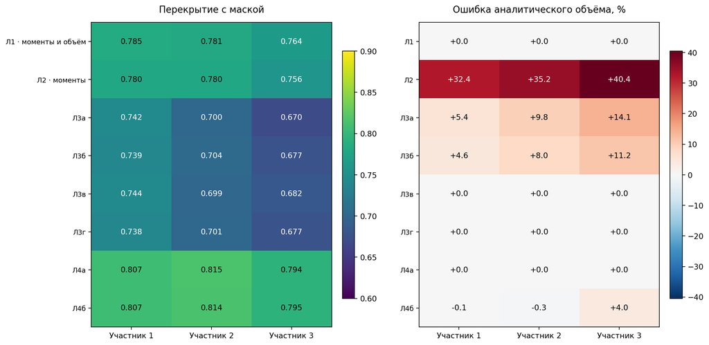

**Рисунок 3. Перекрытие и ошибка объёма для разных способов построения эллипсоида.** Методы Л3 подбирают параметры по расстоянию до поверхности; методы Л4 — по перекрытию. Сочетания фиксированных и свободных центра и объёма заданы в реестре. Отсутствие сошедшегося решения обозначается явно и не заменяется нулевой ошибкой.

Эллипсоид, сохраняющий вторые моменты без приведения к объёму, завышает объём примерно на 32–40% в показанных примерах. Приведение к объёму устраняет это расхождение, но меняет вторые моменты фигуры. Выбор между критериями должен определяться задачей замещения, а не одним лучшим числом Dice. Методы проекта и найденные MATLAB-реализации сохраняются как отдельные позиции даже при близких результатах.

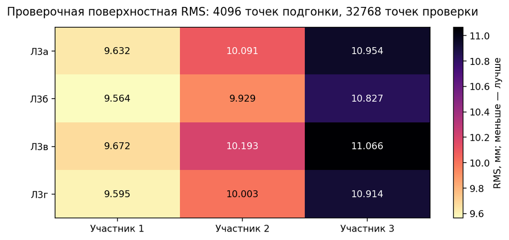

**Рисунок 3, дополнительная панель. Проверочная ошибка расстояния до поверхности для методов Л3.** Подгонка использовала 4096 точек, оценка — общую более плотную площадочную выборку из 32 768 точек. Показано среднеквадратическое расстояние до поверхности, RMS, в миллиметрах; меньшее значение означает лучшее соответствие поверхности по этому критерию. Дополнительная выборка проверяет численное приближение поверхности, но не является независимым анатомическим референсом.

У участника 3 увеличение выборки подгонки Л3а с 1024 до 4096 точек уменьшило проверочную RMS с 11,005 до 10,954 мм. Одновременно Dice снизился на 0,0191 до 0,6697. Следовательно, по одной матрице Dice можно было бы ошибочно заключить, что подгонка стала хуже во всех отношениях. Фактически улучшился именно критерий близости поверхности, а пространственное перекрытие уменьшилось.

Для методов Л4 переход от решётки подгонки 3 мм к 2 мм изменил итоговый Dice не более чем на 0,00161, но найденный центр сместился до 1,825 мм. У участника 3 свободный объём Л4б изменился на 3,03 процентного пункта относительно объёма маски; порядок Л4а и Л4б по Dice поменялся. На рисунке сохранён результат решётки 2 мм. Малое изменение Dice пока не подтверждает устойчивость координат, свободного объёма или предпочтения этих методов — особенно для последующего анализа чувствительности к перемещению.

## 4.1. Отдельное сравнение библиотечных реализаций

Для девяти MATLAB-вариантов выполнены отдельные расчёты на тех же трёх поверхностях: BOOK, TAUB, HES, SOD, FC и 2-NORM из пакета hyperellipsoidfit; сферический и эллипсоидальный режимы ellipsoid_fit; SphereFit. Версии пакетов и соответствие обозначений зафиксированы в реестре. Их тождество историческим реализациям РФФИ не предполагается.

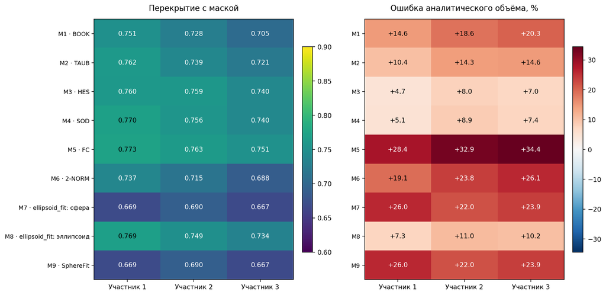

**Рисунок 4. Геометрические результаты девяти MATLAB-реализаций.** Показатели имеют те же определения, что на рисунках 2 и 3. Для показанного результата использовано 32 768 точек, выбранных по площади непосредственно из полной поверхности каждой исходной маски. Библиотечные варианты показаны отдельно от методов проекта. Каждая допустимая фигура проверяется на той же маске, а не только по внутреннему критерию библиотеки.

При переходе от 4096 к 8192 точкам в первом библиотечном опыте все 54 подгонки дали допустимые фигуры. Однако для близких результатов обнаружены изменения порядка методов: одна пара поменяла порядок по Dice, ещё две — по среднеквадратическому расстоянию до поверхности. Максимальное изменение Dice составило около 0,00173, координат центра — 0,64 мм. Поэтому небольшие различия соседних методов пока не дают устойчивого основания для выбора. В этом опыте проверялось прореживание общего набора из 8192 точек; затем выполнена отдельная проверка 32 768 точек непосредственно из полной поверхности. Во втором сравнении все 27 новых подгонок дали допустимые фигуры. По отношению к 8192 точкам максимальное изменение центра составило 0,366 мм, объёма — 0,656%, Dice — 0,00275. Для одной пары сохранилось изменение порядка по поверхностной ошибке. Таким образом, численно близкие варианты пока следует рассматривать как неразделённые с учётом выполненной проверки, а не назначать им окончательные места.

## 4.2. Проверка зависимости от фазы

Для сферы с подгонкой поверхности при фиксированном объёме и алгебраически подбираемой сферы выполнены 78 расчётов: два метода на всех 39 доступных фазах целого сердца. В этом пофазном опыте подгонка использует 4096 точек, поверхностная оценка — 8192; полная подгонка по всем точкам выполнена только для трёх примеров раздела 4. Из основной сводки исключены шесть опорных фаз, оставлены 33. Параметры определяются отдельно по каждой целевой фазе; это проверка геометрического описания, а не предсказание неизвестной фазы.

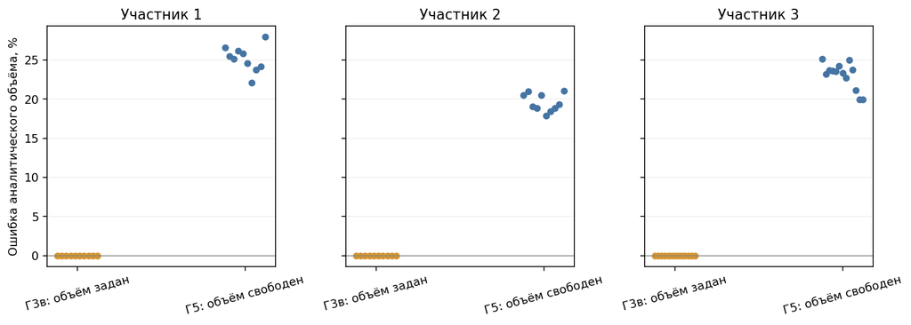

**Рисунок 5. Ошибки объёма в неопорных фазах.** Каждая точка относится к одной фазе. Раздельные панели сохраняют различие участников; межсубъектная статистическая значимость здесь не оценивается.

Сохранение объёма у метода Г3в обеспечивается ограничением задачи. Свободная алгебраическая подгонка Г5 даёт систематически другой объём. Различия фаз включают истинное изменение геометрии, особенности реконструкции и сегментации. Разделить эти источники по автоматическим маскам без независимого референса нельзя.

## 5. Электрический отклик трёх форм

Электрический опыт выполнен на отдельной статической FEM-модели Nix. Исходная сердечная область заменялась сферой равного объёма и эллипсоидом по моментам с приведением к объёму. Их аналитические объёмы одинаковы: приблизительно 782,892 мл. Объёмы дискретных материальных областей составляют соответственно 782,892; 784,390 и 781,555 мл. Эта статическая область не отождествляется с автоматической маской какой-либо из показанных 4D-фаз.

По принятому автором допущению фон неподвижен. На месте исходного сердца в фоне задаются мягкие ткани; лёгкие и кости сохраняют свои материалы. Новая сердечная область накладывается на фон с приоритетом сердечного материала. После её перемещения освобождённая область получает материал исходного фона. Эта постановка описывает изменение материальной карты, не моделируя механическую деформацию соседних органов.

Использована действительная скалярная модель проводимости при частоте 50 кГц и полная электродная модель контакта. Диаметр контактов — 5 мм. Удельные сопротивления приняты по центральному состоянию ранее заданной расчётной сетки TEPC; это параметры модели, а не измеренные характеристики данного человека. Сердце рассматривается как эффективная смесь крови и миокарда. Ёмкостная составляющая тканей в этом опыте не учитывается.

| Область | ρ, Ом·м |
| --- | --- |
| Мягкие ткани | 12.9755 |
| Эффективное целое сердце | 3.2719 |
| Лёгкие | 6.7793 |
| Кости | 48.4451 |

Для каждой новой геометрии матрицы материалов собраны заново средствами EIDORS. Для каждой сборки выполнено отдельное решение с её контактами. Проверены невязка уравнений, баланс токов и взаимность. Эти проверки устанавливают численную согласованность решения; физическая и пространственная валидация требуют отдельных опытов.

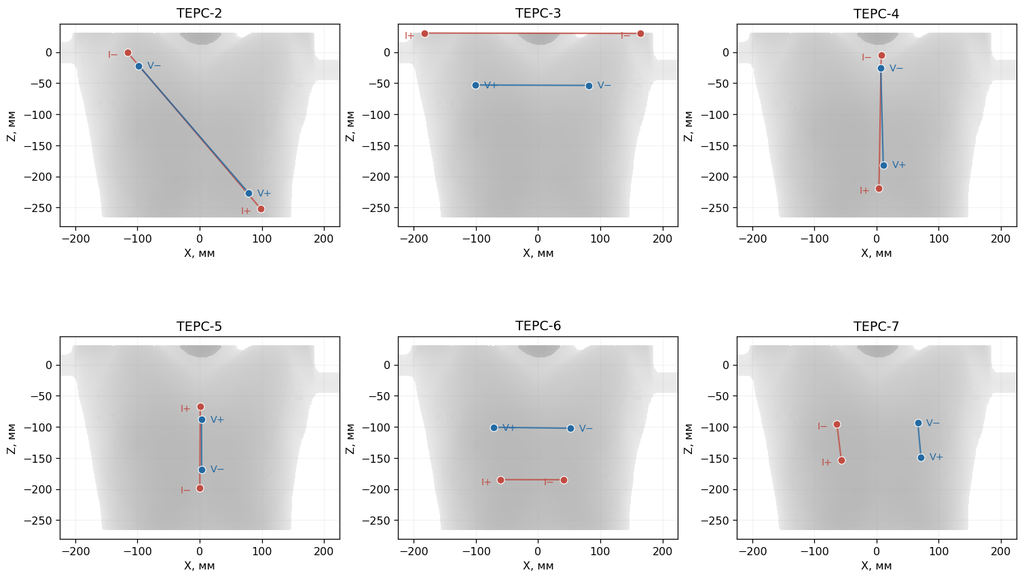

**Рисунок 6. Расположение электродов TEPC-2–TEPC-7 в используемой модели.** Сопоставление ниже относится к этим сохранённым координатам контактов. Номер сборки не определяет её чувствительность без геометрии, назначения электродов и параметров расчёта.

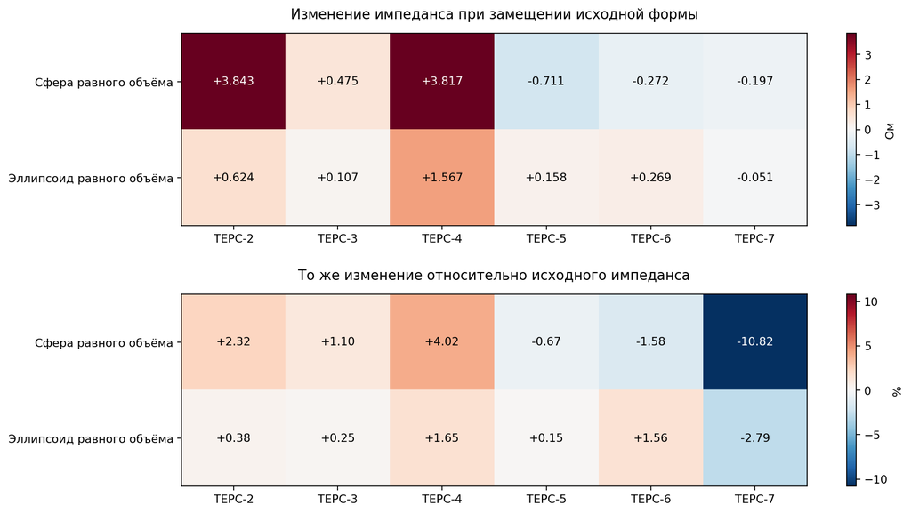

| Сборка | Исходная форма, Ом | Сфера, Ом | Эллипсоид, Ом |
| --- | --- | --- | --- |
| TEPC-2 | 165.7984 | 169.6419 | 166.4224 |
| TEPC-3 | 43.0312 | 43.5061 | 43.1378 |
| TEPC-4 | 95.0376 | 98.8550 | 96.6044 |
| TEPC-5 | 105.5296 | 104.8184 | 105.6874 |
| TEPC-6 | 17.2472 | 16.9754 | 17.5159 |
| TEPC-7 | 1.8208 | 1.6237 | 1.7700 |

**Рисунок 7. Изменение базового импеданса при замещении сердца.** Верхняя матрица показывает $Z_G-Z_0$ в омах, нижняя — $100(Z_G-Z_0)/Z_0$ в процентах, где $Z_0$ — импеданс исходной статической формы, $Z_G$ — импеданс соответствующей фигуры. Знак показывает направление изменения, модуль — величину расхождения. Две шкалы нужны одновременно: малый исходный импеданс может увеличивать относительную ошибку.

В этом опыте модуль ошибки сферы составляет примерно 0,197–3,843 Ом, эллипсоида — 0,051–1,567 Ом. Во всех шести сборках эллипсоид ближе к исходной форме. На TEPC-6 различие между модулями ошибок невелико: приблизительно 0,272 и 0,269 Ом; при этом знаки ошибок противоположны. Следовательно, одинаковый порядок абсолютной ошибки ещё не означает одинакового изменения сигнала.

На TEPC-7 относительная ошибка сферы достигает −10,82%, эллипсоида — −2,79%, хотя абсолютные ошибки сравнительно малы. Исходный импеданс этой сборки составляет около 1,821 Ом. Этот пример показывает роль знаменателя при относительной оценке. Представленные разности описывают замещение базовой геометрии. Они не являются пульсовой амплитудой, производной по объёму или рекомендацией выбирать электроды по величине ошибки замещения.

## 6. Достаточность дискретизации для малых изменений геометрии

На той же неизменной сетке проверены 66 геометрических состояний. Сфера и эллипсоид переносились на ±0,5; ±1; ±2 и ±4 мм по каждой оси. Их объёмы изменялись на ±0,5; ±1; ±2 и ±4% при неизменном центре и сохранении отношений полуосей. Эти значения задают численные пробы, а не физиологические амплитуды движения.

Для линейного переноса точная геометрическая производная объёма равна нулю. При изменении заданного объёма производная воспроизведённого объёма по заданному должна быть равна единице. Эти известные значения позволяют проверить передачу изменения геометрии в материальную карту ещё до электрического решения.

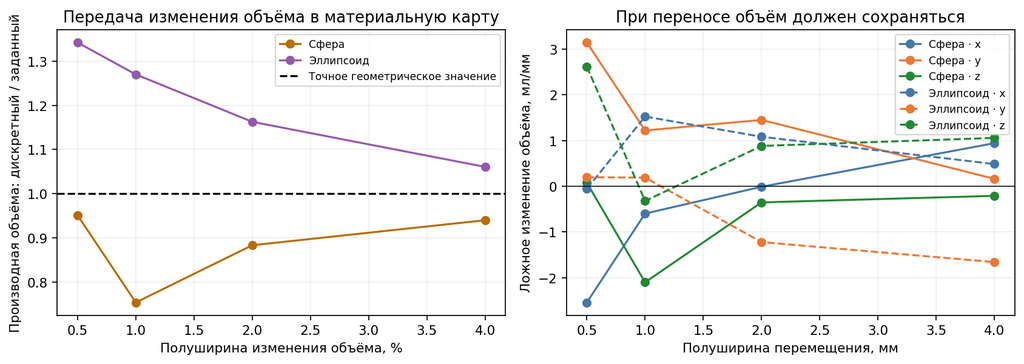

**Рисунок 8. Проверка передачи малых изменений в дискретную геометрию.** Слева показана центральная разностная оценка производной объёма; точное значение равно 1. Справа показано ложное изменение дискретного объёма при переносе; точное значение равно 0. Зависимость от шага отражает влияние назначения целых тетраэдров одному материалу.

Для сферы оценка производной объёма составляет приблизительно 0,75–0,95 вместо 1, для эллипсоида — 1,06–1,34. При переносе возникает ложная производная объёма до 3,14 мл/мм по модулю. Следовательно, малая ошибка объёма в одном состоянии не подтверждает точность его малого изменения. Электрическая ошибка из этих чисел непосредственно не определяется, но этот источник погрешности необходимо устранить или ограничить до оценки геометрических чувствительностей.

В области сердца характерная длина рёбер текущих тетраэдров составляет около 16 мм. Размер КТ-вокселя не задаёт автоматически ни размер этих элементов, ни точность интегрирования материала в них. Проверяются два дополнительных механизма: учёт частичного заполнения граничного элемента сердечным материалом и пространственное сгущение FEM-сетки. Первый улучшает описание границы; второй также уточняет электрическое поле. Улучшение одного механизма не подтверждает сходимость другого.

## 6.1. Учёт частичного заполнения конечных элементов

Вместо присвоения граничному тетраэдру только одного материала рассчитана доля его объёма, занятая сердцем. Оставшаяся доля сохраняет исходный фоновый материал. Проверены те же 66 состояний на трёх уровнях интегрирования: 64, 512 и 4096 точек в граничном элементе. Все тетраэдры исходной сетки проверены на возможное пересечение; отбор только по координатам центров не использовался.

Для линейного тетраэдрального элемента градиенты базисных функций постоянны. Поэтому элементная матрица определяется интегралом проводимости по элементу:

$$K_{ij}^{(e)}=\left[\sigma_h f_e+\sigma_b(1-f_e)\right] |T_e|\,\nabla N_i\cdot\nabla N_j,$$

где $T_e$ — тетраэдр, $|T_e|$ — его объём; $N_i$ и $N_j$ — линейные базисные функции; $f_e$ — доля сердечной области в элементе; $\sigma_h$ и $\sigma_b$ — проводимости сердечного и фонового материалов. Формула точно задаёт интеграл для данного пространства линейных функций при точной доле $f_e$. Она не обеспечивает автоматического разрешения изменения электрического поля на внутренней границе материалов.

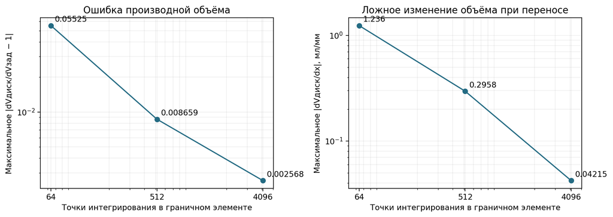

| Точек в элементе | Максимальная ошибка объёма, % | Максимальная ошибка производной объёма, % |
| --- | --- | --- |
| 64 | 0.1252 | 5.525 |
| 512 | 0.0243 | 0.866 |
| 4096 | 0.0059 | 0.257 |

**Рисунок 9. Уменьшение ошибки геометрических производных при уточнении доли сердечного материала.** Обе оси каждого графика логарифмические; приведены максимальные ошибки среди проверенных состояний. Переход между уровнями уточняет интегрирование на той же FEM-сетке.

При 4096 точках максимальная ошибка объёма уменьшилась до 0,0059%, максимальное отклонение производной объёма от единицы — до 0,257%. Ложная производная объёма при переносе уменьшилась до 0,0422 мл/мм. Это существенное улучшение относительно назначения материала по центру элемента. Проверены границы долей, восстановление фонового материала и предельный случай одинаковых проводимостей. Результат относится к геометрическому интегрированию; точность электрической производной требует прямого решения и проверки пространственной сходимости.

## 6.2. Первый расчёт чувствительности импеданса к объёму

После проверки частичного заполнения выполнены 13 электрических решений для TEPC-2. При 4096 точках интегрирования рассчитаны сфера и эллипсоид в базовом состоянии и при изменениях объёма ±0,5% и ±1%. Для сферы базовое состояние и пара ±0,5% дополнительно рассчитаны при 512 точках. Центры фигур, отношения полуосей, электроды и свойства тканей фиксированы. Изменение объёма каждой фигуры реализовано равномерным масштабированием.

Производная импеданса и относительная чувствительность определены как

$$S_V\approx\frac{Z(V_0+\delta V)-Z(V_0-\delta V)}{2\delta V},\qquad E_V=\frac{V_0}{Z_0}S_V,$$

где $V_0$ — заданный аналитический объём фигуры, $\delta V$ — полуширина возмущения, $Z_0=Z(V_0)$ — базовый импеданс. Производная $S_V$ измеряется в Ом/мл; её модуль характеризует величину абсолютной чувствительности. Безразмерная величина $E_V$ показывает относительное изменение импеданса при малом относительном изменении объёма. Например, увеличение объёма на 1% в линейном приближении даёт изменение импеданса на $E_V$ процентов. В знаменателе разностной оценки используется заданное изменение аналитического объёма, а не фактически получившееся изменение дискретного объёма: последняя подстановка могла бы скрыть часть ошибки представления геометрии.

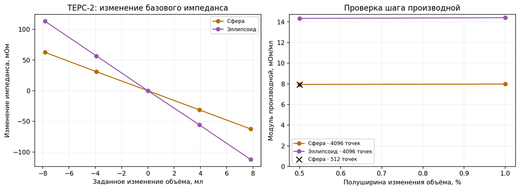

| Фигура | Точек в элементе | Полуширина, % | dZ/dV, мОм/мл | Относительная чувствительность |
| --- | --- | --- | --- | --- |
| Сфера | 4096 | 0.5 | -7.9412 | -0.03668 |
| Сфера | 4096 | 1.0 | -7.9806 | -0.03687 |
| Эллипсоид | 4096 | 0.5 | -14.3345 | -0.06754 |
| Эллипсоид | 4096 | 1.0 | -14.4055 | -0.06787 |
| Сфера | 512 | 0.5 | -7.9319 | -0.03664 |

**Рисунок 10. Электрическая реакция на малое изменение объёма при частичном заполнении элементов.** Слева показан знак и величина изменения импеданса, справа — модуль производной при двух шагах. Дополнительный крест показывает контроль менее подробного интегрирования. Это вычислительный опыт на одной сборке и одном состоянии свойств тканей.

При полуширине ±0,5% производная составляет приблизительно −7,94 мОм/мл для сферы и −14,33 мОм/мл для эллипсоида. В рамках принятой модели увеличение объёма на 1 мл соответствует уменьшению импеданса примерно на эти величины. Это локальное линейное толкование производной; увеличение объёма целого эффективного сердца не отождествляется с ударным объёмом желудочка.

Уменьшение полуширины с ±1% до ±0,5% изменило производную приблизительно на 0,496% для обеих фигур. Для сферы переход от 512 к 4096 точкам при полуширине ±0,5% изменил её приблизительно на 0,118%. Получены небольшие различия в выполненных численных проверках. Допуск пригодности производной заранее не был установлен, поэтому эти числа не объявляются сертификатом сходимости. Не проверены пространственное сгущение электрического поля, другие сборки, другие сопротивления и ошибки модели.

Модуль производной эллипсоида примерно в 1,81 раза больше модуля производной сферы. Следовательно, близость базовых импедансов не задаёт близости геометрических чувствительностей. На этом шаге индивидуальная форма ещё не была рассчитана. Поэтому полученные значения позволяли установить различие двух фигур, но не ошибку каждой из них относительно индивидуальной формы. Следующий опыт восполняет этот пробел.

## 6.3. Сравнение с исходной индивидуальной формой

**Статус: результат математической модели; численная проверка продолжается.** Для статической FEM-модели рассчитаны ещё пять состояний: исходная индивидуальная форма и её равномерное увеличение и уменьшение по объёму на 0,5% и 1%. Сохранены сборка TEPC-2, конечные контактные площадки диаметром 5 мм, контактное сопротивление, свойства тканей и частота 50 кГц. Данные 4D-КТ в этом опыте не используются.

Индивидуальная область определена объединением 1963 тетраэдров, которым в исходной FEM назначен сердечный материал. Её объём составляет $V_0=782{,}891854$ мл. Это вычислительное описание целого эффективного сердца, включающего кровь и миокард. Оно служит геометрическим ориентиром электрического сравнения, но не является независимым анатомическим эталоном и не задаёт объём полости желудочка.

Преобразование каждой точки сердечной области задаётся формулой

$$\mathbf{x}'=\mathbf{c}_0+(1+\varepsilon)^{1/3} (\mathbf{x}-\mathbf{c}_0),$$

где $\mathbf{c}_0$ — объёмный центр исходной области, $\varepsilon\in\{-0{,}01;-0{,}005;0;0{,}005;0{,}01\}$ — заданное относительное изменение объёма. Центр и особенности формы сохраняются; новый аналитический объём равен $V_0(1+\varepsilon)$. Такое преобразование выбрано для контролируемого сравнения. Физиологическим законом сокращения сердца оно не объявляется.

Область сердца проверяется по принадлежности объединению исходных тетраэдров. Замена её выпуклой оболочкой не выполняется. Доли сердечного материала интегрируются на неизменной электрической сетке по вложенным наборам точек последовательности Соболя. Во всех возмущённых состояниях используются одинаковые точки. Это детерминированная численная проверка; доверительные интервалы случайной погрешности из неё не выводятся. При нулевом преобразовании они точно воспроизводят исходные тканевые метки. Повторное решение отличается от прежнего импеданса индивидуальной формы менее чем на $5\cdot10^{-10}$ Ом. Это проверка согласованности назначения материалов и прямого решения.

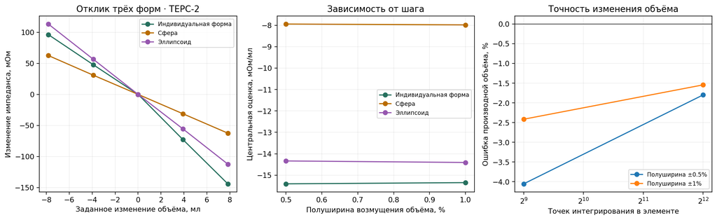

| Представление | Полуширина, % | dZ/dV, мОм/мл | Отличие производной от индивидуальной формы, % |
| --- | --- | --- | --- |
| Индивидуальная форма | 0.5 | -15.4037 | 0.00 |
| Сфера | 0.5 | -7.9412 | 48.45 |
| Эллипсоид | 0.5 | -14.3345 | 6.94 |
| Индивидуальная форма | 1 | -15.3463 | 0.00 |
| Сфера | 1 | -7.9806 | 48.00 |
| Эллипсоид | 1 | -14.4055 | 6.13 |

**Рисунок 11. Сопоставление чувствительности индивидуальной формы, сферы и эллипсоида на исходной FEM-сетке.** Слева показано изменение импеданса относительно собственного исходного состояния каждой формы. В центре сопоставлены производные при двух полуширинах возмущения. Справа показана ошибка воспроизведения заданного изменения объёма индивидуальной формы при уточнении интегрирования. Отрицательная ошибка означает, что расчётная материальная область изменилась меньше, чем задано. Все три панели описывают один вычислительный опыт; перенос вывода на другие сборки требует отдельного расчёта.

При 4096 точках интегрирования и полуширине ±0,5% производная индивидуальной формы составила −15,40 мОм/мл, сферы — −7,94 мОм/мл, эллипсоида — −14,33 мОм/мл. Относительное различие производных с индивидуальной формой составляет соответственно около 48,45% для сферы и 6,94% для эллипсоида. При полуширине ±1% различия составляют около 48,00% и 6,13%. В данной постановке эллипсоид лучше воспроизводит электрический эффект равномерного изменения объёма исходной формы.

Отрицательный знак означает уменьшение измеряемого импеданса при увеличении объёма. Модуль производной задаёт величину этого эффекта. Различие фигур имеет пространственную причину: при одном и том же приращении объёма их границы захватывают разные участки фоновых тканей. Электрическое поле и чувствительность сборки в этих участках неодинаковы. Равенство объёма и центра поэтому не требует равенства производной.

### Почему проверки шага недостаточно

При уменьшении полуширины с ±1% до ±0,5% производная индивидуальной формы изменилась примерно на 0,37%. Однако при тех же 4096 точках воспроизведение самого изменения объёма имеет отклонение около 1,8%. Оно оценивается независимо от электрического решения:

$$D_V=\frac{V_{\mathrm{mat}}(+\varepsilon)-V_{\mathrm{mat}}(-\varepsilon)} {2\varepsilon V_0},\qquad e_{D_V}=100(D_V-1),$$

где $V_{\mathrm{mat}}$ — объём, полученный суммированием долей сердечного материала в конечных элементах. Для точного представления заданного масштабирования $D_V=1$. При полуширине ±0,5% получены значения 0,95946 для 512 точек и 0,98203 для 4096 точек. При полуширине ±1% — 0,97585 и 0,98457 соответственно.

Максимальная ошибка отдельных объёмов при этом не превышала 0,026%. Противоречия нет: производная определяется разностью двух близких объёмов, поэтому небольшие ошибки каждого объёма могут быть существенны относительно этой разности. Аналогично, близкие значения электрической производной при двух шагах могут содержать общую систематическую ошибку. В знаменателе электрической производной сохранено заданное изменение объёма: подстановка фактически получившегося изменения скрыла бы часть проверяемой ошибки.

Дальнейшая численная проверка разделена на два действия. Сначала увеличивается число точек интегрирования при неизменной FEM-сетке. Затем локально уточняется сама сетка около сердца при сохранении наружной поверхности и точных контактных площадок электродов. Первое действие проверяет назначение материалов, второе — разрешение электрического поля. Размер исходного КТ-вокселя не заменяет ни одну из этих проверок.

## 6.4. Уточнение интегрирования индивидуальной формы

Число точек интегрирования увеличено с 4096 до 16 384 при неизменных сердечной геометрии, электрической сетке и физических параметрах. Дополнительно проверен промежуточный уровень 8192 точек для геометрических объёмов. Для электрического сравнения заново собраны матрицы и решены пять состояний при 16 384 точках.

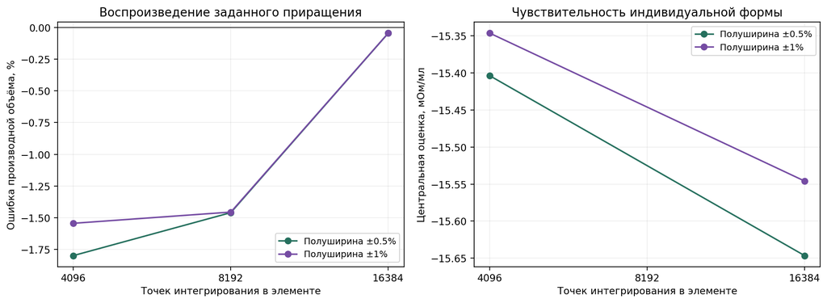

| Представление | Точек в элементе | Полуширина, % | dZ/dV, мОм/мл | Отличие от индивидуальной формы, % |
| --- | --- | --- | --- | --- |
| Индивидуальная форма | 16384 | 0.5 | -15.6465 | 0.00 |
| Сфера | 4096 | 0.5 | -7.9412 | 49.25 |
| Эллипсоид | 4096 | 0.5 | -14.3345 | 8.39 |
| Индивидуальная форма | 16384 | 1 | -15.5459 | 0.00 |
| Сфера | 4096 | 1 | -7.9806 | 48.66 |
| Эллипсоид | 4096 | 1 | -14.4055 | 7.34 |

**Рисунок 12. Влияние точности интегрирования на геометрическую и электрическую производные индивидуальной формы.** Слева показано отклонение производной материального объёма от её точного значения, равного единице. Справа показана производная импеданса на той же FEM-сетке. Электрические решения при 8192 точках не выполнялись; соответствующая точка показана только слева. В таблице указано фактическое число точек для каждой фигуры: прежние результаты сферы и эллипсоида рассчитаны при 4096 точках.

При полуширине ±0,5% ошибка производной материального объёма уменьшилась с −1,797% до −0,0456%; при полуширине ±1% — с −1,543% до −0,0452%. Уменьшение ошибки по уровням было неравномерным: промежуточный уровень 8192 точек давал отклонения около −1,46%. Поэтому пригодность производной проверяется по её фактическим значениям, а не по одному лишь числу точек.

Уточнённая центральная разностная оценка для индивидуальной формы составляет **−15,65 мОм/мл** при полуширине ±0,5% и **−15,55 мОм/мл** при полуширине ±1%. Переход от 4096 к 16 384 точкам изменил эти значения приблизительно на 1,55% и 1,28% относительно более подробного расчёта. Различие двух шагов при 16 384 точках составляет около 0,64%. Небольшое различие по шагу, полученное ранее, действительно не охватывало всю ошибку интегрирования.

Относительно уточнённой индивидуальной формы отклонение производной сферы составляет около **49,25%**, эллипсоида — **8,39%** при полуширине ±0,5%. При полуширине ±1% — около 48,66% и 7,34%. Предварительное предпочтение эллипсоида сохранилось после этой проверки. Однако число точек интегрирования у сравниваемых фигур различается; влияние этого различия на их предпочтение ещё необходимо проверить. Различие эллипсоида с индивидуальной формой также сохранилось; считать их электрически эквивалентными на основании этого опыта нельзя.

Полученная ошибка производной объёма характеризует интегрирование материалов. Она не является верхней границей ошибки электрической производной: разные участки границы вносят разный вклад в сигнал. Проверка электрического поля на более подробной сетке, переносы, другие сборки и свойства тканей остаются необходимыми.

## 6.5. Различие отклика при увеличении и уменьшении объёма

На левой панели рисунка 11 показано изменение импеданса индивидуальной формы по обе стороны исходного состояния. Для количественного сравнения наклонов этих ветвей рассчитаны две односторонние конечные разности, представленные на рисунке 13:

$$S_- = \frac{Z(V_0)-Z(V_0-\delta V)}{\delta V},\qquad S_+ = \frac{Z(V_0+\delta V)-Z(V_0)}{\delta V}.$$

Центральная оценка равна их среднему: $S_c=(S_-+S_+)/2$. Стабильность среднего при уменьшении шага не требует совпадения двух односторонних оценок. Существование единственной производной при стремлении шага к нулю таким тестом не установлено.

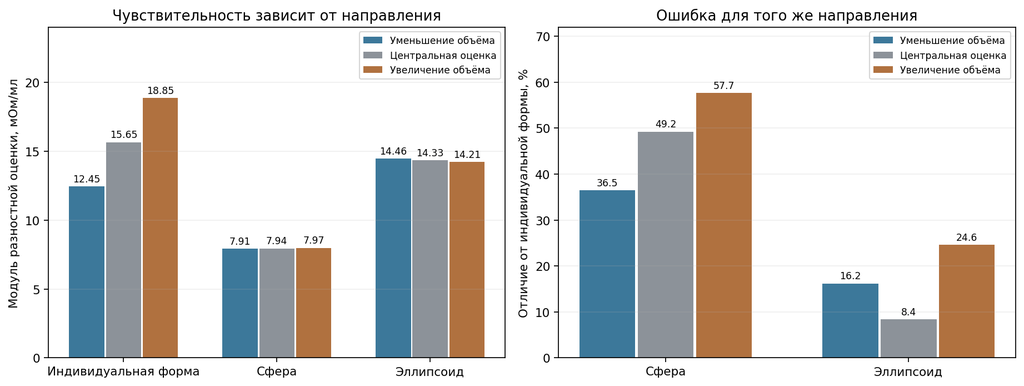

| Изменение объёма | В исходных мягких тканях, мл | В исходном лёгком, мл | В исходной области сердца, мл | Всего, мл |
| --- | --- | --- | --- | --- |
| -0.5% | +0.446 | +0.028 | -4.390 | -3.915 |
| +0.5% | +3.556 | +0.830 | -0.476 | +3.910 |

**Рисунок 13. Односторонние и центральные оценки при полуширине изменения объёма 0,5%.** Слева показаны модули оценок; все подписанные значения в исходном расчёте отрицательны. Справа каждая фигура сравнивается с индивидуальной формой для того же направления изменения объёма. Для индивидуальной формы использованы 16 384 точки интегрирования, для двух приближений — 4096. Таблица ниже показывает изменение объёма сердечного материала в областях разных исходных тканей. Положительное число означает появление сердечного материала, отрицательное — его уход с восстановлением принятого фона.

Для индивидуальной формы получены $S_-=-12{,}45$ и $S_+=-18{,}85$ мОм/мл. Их различие составляет около 40,9% модуля центральной оценки. При полуширине 1% оно остаётся около 39,5%. У сферы и эллипсоида при полуширине 0,5% соответствующие различия составляют около 0,85% и 1,78%. Асимметрия индивидуальной формы сохранилась после уточнения интегрирования, поэтому её нельзя объяснить одной лишь прежней неточностью приращения объёма.

Эллипсоид ближе сферы к индивидуальной форме в обоих направлениях этого опыта. Однако его отклонение составляет около 16,2% при уменьшении объёма и 24,6% при увеличении. Для сферы получены около 36,5% и 57,7%. Следовательно, центральное различие 8,39% не является общей ошибкой воспроизведения любых малых изменений объёма.

**Причина асимметрии пока не разделена.** Проверяются по меньшей мере два механизма. Первый связан с электрической дискретизацией: исходная граница сердца совпадает с гранями элементов, а поле внутри и снаружи представлено разными постоянными градиентами. Смешение проводимостей в пересечённом элементе не разрешает скачок градиента внутри него. Второй связан с принятым фоном: освободившаяся исходная область сердца становится мягкой тканью, тогда как растущая форма может замещать также лёгкое. Это разные материальные изменения даже при одинаковом изменении полного объёма.

Баланс материалов подтверждает различие сценариев, но не устанавливает его вклад в импеданс. Например, при увеличении объёма на 0,5% в исходной области лёгкого появляется около 0,830 мл сердечного материала; при уменьшении — около 0,028 мл. Появление новой занятой области возможно даже при уменьшении полного объёма: равномерно масштабированные невыпуклые области не обязаны быть вложенными. Одновременно часть прежней области освобождается; суммарный объём изменяется в заданном направлении. Это следствие выбранного преобразования индивидуальной формы, а не утверждение о физиологическом перемещении тканей. Вклад области кости в данном балансе менее 0,001 мл; в таблице он опущен.

Следующая проверка должна сопоставлять $S_-$ и $S_+$ при локальном сгущении сетки. Для разделения материального механизма нужен отдельный контроль с одинаковым фоновым материалом в окрестности движущейся границы, с сохранением основного принятого неоднородного фона как рабочей постановки. До этих проверок основной результат — сравнение конечных изменений $\Delta Z$, а центральная разность служит дополнительной сводной оценкой.

## 6.6. Первое локальное уточнение электрической сетки

Сетка уточнена в области, охватывающей индивидуальную форму, сферу, эллипсоид и их изменения объёма ±1%. Все выбранные внутренние рёбра разделены согласованно во всех прилегающих тетраэдрах. Рёбра наружной поверхности явно исключены из этого разбиения. Таким образом, сохранены положение тела, исходные вершины, порядок наружных граней и заданная геометрия контактных площадок. Эта постановка проверяет внутреннюю дискретизацию поля при прежней поверхностной сетке.

| Показатель | Исходная сетка | Уточнённая сетка |
| --- | --- | --- |
| Узлы | 791 141 | 821 731 |
| Тетраэдры | 4 448 426 | 4 630 591 |
| Наружные треугольники | 351 620 | 351 620 |
| Объём исходной сердечной области, мл | 782,891854 | 782,891854 |
| Базовый импеданс TEPC-2, Ом | 165,798449 | 166,417493 |

Отмечено 30 590 внутренних рёбер. Все полученные тетраэдры имеют положительные объёмы; объёмы родительских элементов и их тканевые метки сохранены. Контактная матрица после учёта новой нумерации внутренних степеней свободы совпадает с прежней. Относительное различие полной собранной матрицы и матрицы EIDORS составляет около $10^{-17}$. Проверки невязки решения, токового баланса и взаимности также выполнены.

При совершенно одинаковой исходной форме сердца и свойствах тканей базовый импеданс изменился на **+0,619 Ом**, или **+0,373%**. Это установленное различие двух дискретизаций. Оно не является оценкой полной ошибки относительно непрерывного решения и не доказывает пространственную сходимость.

Этот сдвиг важен для интерпретации прежнего сравнения форм. Нельзя сопоставлять уточнённое индивидуальное сердце с прежними фигурными результатами как один опыт: сферу и эллипсоид нужно рассчитать на той же уточнённой сетке. Нельзя также переносить процент изменения базового импеданса на процент ошибки чувствительности. Ошибки двух возмущённых состояний могут быть связаны и частично сокращаться при вычитании. Поэтому следующий блок расчёта должен прямо сравнить $\Delta Z$, центральную и обе односторонние оценки между сетками для каждой формы.

**Промежуточный итог первого этапа.** Получены проверяемый расчёт индивидуальной формы, уточнение интегрирования и базовый контроль новой внутренней сетки. Выявлены два ограничения — асимметрия реакции на изменение объёма и зависимость базового решения от сетки. Численная проверка первого этапа ещё не завершена. Расчёты переноса, остальных сборок и совмещения с 4D-КТ следуют после разбора этих вопросов.

## 7. Выводы и дальнейшее сравнение

1. **Для геометрического ориентира сохраняется автоматическая маска целевой фазы.** Её независимая анатомическая проверка остаётся отдельной задачей. Индивидуальная опорная форма служит самостоятельным кандидатом сокращённого описания и требует меньше пофазной геометрической информации.
2. **Для первого сокращённого электрического приближения обоснованно продолжать проверку эллипсоида равного объёма.** В данном статическом опыте он лучше сферы равного объёма по базовому импедансу во всех сборках. В опыте равномерного изменения объёма на TEPC-2 его производная также оказалась ближе к производной индивидуальной формы. Численная точность этого нового сравнения ещё уточняется: число точек интегрирования индивидуальной формы и фигур различается. Кроме того, обнаружены различие односторонних оценок индивидуальной формы и зависимость базового решения от сетки. Это предварительный выбор для дальнейших проверок, а не общий победитель среди всех методов и участников.
3. **Сравнение малых геометрических чувствительностей требует уточнения материальной дискретизации.** Назначение материалов по центрам элементов искажает заданные изменения объёма; частичное заполнение уже уменьшило эту ошибку. Далее нужно проверять одновременно шаг возмущения, интегрирование границы и FEM-сетку. Для индивидуальной формы необходимо раздельно проверять увеличение и уменьшение объёма: центральная оценка скрывает выявленную асимметрию.
4. **Окончательное предпочтение должно выдерживать проверку на исключённых данных.** Требуются другие фазы, участники, сборки и фоновые сопротивления. Подгонка формы по одной сборке не устанавливает её пригодность для другой. Для перехода к ударному объёму и фракции выброса дополнительно нужна связь параметров приближения с проверенными объёмами камер.

## Приложение. Полные численные результаты методов проекта

Таблица показывает выбранную итоговую редакцию каждого сочетания метода и маски. Предыдущие попытки сохранены отдельно, включая отказы и проверки уточнения. Основная интерпретация дана выше. Детальные параметры, состояния оптимизации и контрольные суммы входят в машиночитаемые результаты. Неудачная попытка не является доказательством непригодности математического метода.

| Метод | Участник 1: Dice / ошибка V | Участник 2 | Участник 3 |
| --- | --- | --- | --- |
| Маска целевой фазы | 1.000 / +0.00% | 1.000 / +0.00% | 1.000 / +0.00% |
| Индивидуальная форма | 0.869 / +0.00% | 0.862 / +0.00% | 0.879 / +0.00% |
| Индивидуальная + поворот | 0.860 / +0.00% | 0.833 / -0.00% | 0.870 / +0.00% |
| Индивидуальная + три масштаба | 0.858 / +0.00% | 0.829 / -0.00% | 0.870 / +0.00% |
| Г1 · равный объём | 0.675 / -0.00% | 0.714 / -0.00% | 0.673 / -0.00% |
| Г2 · второй момент | 0.641 / +67.11% | 0.688 / +54.76% | 0.647 / +68.79% |
| Г3а · поверхность, центр задан | 0.677 / +15.70% | 0.717 / +14.15% | 0.680 / +13.03% |
| Г3б · поверхность, центр свободен | 0.673 / +15.42% | 0.699 / +12.85% | 0.669 / +11.77% |
| Г3в · поверхность, объём задан | 0.672 / -0.00% | 0.694 / -0.00% | 0.663 / -0.00% |
| Г4а · перекрытие, объём задан | 0.678 / -0.00% | 0.718 / -0.00% | 0.677 / -0.00% |
| Г4б · перекрытие, объём свободен | 0.681 / +11.94% | 0.723 / +12.13% | 0.684 / +20.61% |
| Г5 · алгебраический критерий | 0.669 / +26.07% | 0.690 / +22.05% | 0.667 / +23.69% |
| Л1 · моменты и объём | 0.785 / -0.00% | 0.781 / +0.00% | 0.764 / +0.00% |
| Л2 · моменты | 0.780 / +32.38% | 0.780 / +35.22% | 0.756 / +40.45% |
| Л3а | 0.742 / +5.44% | 0.700 / +9.75% | 0.670 / +14.13% |
| Л3б | 0.739 / +4.58% | 0.704 / +7.99% | 0.677 / +11.20% |
| Л3в | 0.744 / +0.00% | 0.699 / -0.00% | 0.682 / -0.00% |
| Л3г | 0.738 / +0.00% | 0.701 / -0.00% | 0.677 / -0.00% |
| Л4а | 0.807 / +0.00% | 0.815 / -0.00% | 0.794 / -0.00% |
| Л4б | 0.807 / -0.08% | 0.814 / -0.32% | 0.795 / +4.03% |